# act_report

```
     Visualisation Report
```

visualisation is the process of analyising and giving the insight of the provided data using visuals.its important to use visuals in explaining some insights because it aids easy understanding of the dataset. matplotlib and seaborn are the libraries used in visualisation.

firstly, i would put down three insights from the data and explain each one of them.

1* Checking the distribution for the dog stage : in the data provided, we have seven dog stages provided which includes doggo,puppo,pupper,floofer,doggo/puppo,doggo/floofer,doggo/pupper. so i want to see which stage has more dogs in the dataset. from the image below, pupper has the highest count of dogs in the dataset. seaborn was used for the visualisation.

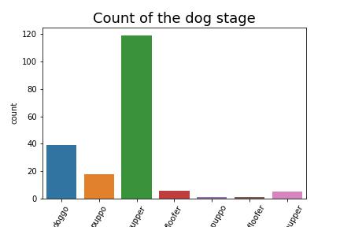

2* checking the distribution for dogs breeds prediction : There are three prediction columns for dog breed. so i will visualize each of the column one after the other.

for p1 column, there are alot of dog breed across the data but am only interested for the top five breeds that occured the most in the p1 column. using pandas function .value_counts().head() i was able to get the first five most appeared breeds as seen in the image below. most occuring dog breed is golden retriever.

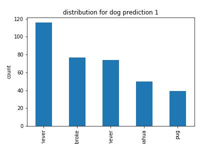

for p2 column, there are alot of dog breed across the data but am only interested for the top five breeds that occured the most in the p2 column. using pandas function .value_counts().head() i was able to get the first five most appeared breeds as seen in the image below. most occuring dog breed is labrador retriever. matplotlib was used for visualisation.

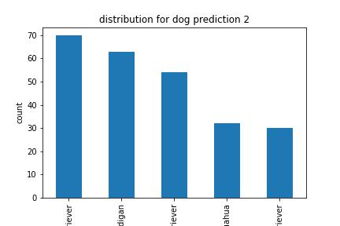

for p3 column, there are alot of dog breed across the data but am only interested for the top five breeds that occured the most in the p3 column. using pandas function .value_counts().head() i was able to get the first five most appeared breeds as seen in the image below. most occuring dog breed is labrador retriever. matplotlib was used for visualisation. Across the three columns of dog breed, it can be said that labrador retriever,golden retriever and chihuahua are the most appeared.

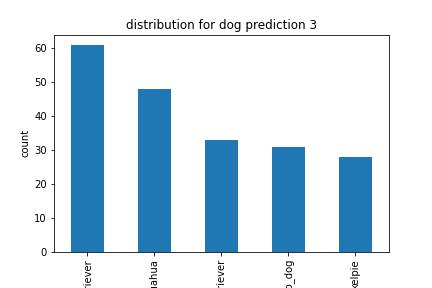

3* Checking the distribution for the tweet source : in the data provided, there are only three major sources of tweet which includes Twitter for i-phone,Twitter Web Client and Tweet Deck .The most used source for tweets is Twitter for i-phone which has count of 1174 as seen below on the chart. used barplot because its a categorical variable. seaborn was used for visualisation

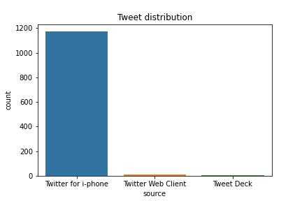